# Hass Avocado Analysis

Jeremy Meguira

October 9, 2018

## Hass Avocado Analysis

This dataset was pulled from: https://www.kaggle.com/neuromusic/avocado-prices/home

It contains historical data on avocado prices and sales volume in a variety of US markets.

Some questions I want to look at in this analysis:

- What happened to avocado prices and consumption in 2017?
- How do the prices of avocados vary by region?

## Load and Examine Dataset

Variable descriptions are provided by the dataset poster:

- Date - The date of the observation
- AveragePrice - the average price of a single avocado
- type - conventional or organic
- year - the year
- Region - the city or region of the observation
- Total Volume - Total number of avocados sold
- 4046 - Total number of avocados with PLU 4046 sold / small hass avocados
- 4225 - Total number of avocados with PLU 4225 sold / large hass avocados
- 4770 - Total number of avocados with PLU 4770 sold / x-large hass avocados

## Clean

Check for duplicate rows

```
## [1] 0
```

Check for missing values

```
## [1] 0
```

Looks like a pretty clean data set. No missing values or duplicated rows. Now let’s look into the individual variables a bit

```
## 'data.frame':    18249 obs. of  14 variables:
##  $ X           : int  0 1 2 3 4 5 6 7 8 9 ...
##  $ Date        : Factor w/ 169 levels "2015-01-04","2015-01-11",..: 52 51 50 49 48 47 46 45 44 43 ...
##  $ AveragePrice: num  1.33 1.35 0.93 1.08 1.28 1.26 0.99 0.98 1.02 1.07 ...
##  $ Total.Volume: num  64237 54877 118220 78992 51040 ...
##  $ X4046       : num  1037 674 795 1132 941 ...
##  $ X4225       : num  54455 44639 109150 71976 43838 ...
##  $ X4770       : num  48.2 58.3 130.5 72.6 75.8 ...
##  $ Total.Bags  : num  8697 9506 8145 5811 6184 ...
##  $ Small.Bags  : num  8604 9408 8042 5677 5986 ...
##  $ Large.Bags  : num  93.2 97.5 103.1 133.8 197.7 ...
##  $ XLarge.Bags : num  0 0 0 0 0 0 0 0 0 0 ...
##  $ type        : Factor w/ 2 levels "conventional",..: 1 1 1 1 1 1 1 1 1 1 ...
##  $ year        : int  2015 2015 2015 2015 2015 2015 2015 2015 2015 2015 ...
##  $ region      : Factor w/ 54 levels "Albany","Atlanta",..: 1 1 1 1 1 1 1 1 1 1 ...
```

The year variable is redundant, as that information is already contained in the date variable, so we can drop it.

```
## 'data.frame':    18249 obs. of  13 variables:
##  $ X           : int  0 1 2 3 4 5 6 7 8 9 ...
##  $ Date        : Factor w/ 169 levels "2015-01-04","2015-01-11",..: 52 51 50 49 48 47 46 45 44 43 ...
##  $ AveragePrice: num  1.33 1.35 0.93 1.08 1.28 1.26 0.99 0.98 1.02 1.07 ...
##  $ Total.Volume: num  64237 54877 118220 78992 51040 ...
##  $ X4046       : num  1037 674 795 1132 941 ...
##  $ X4225       : num  54455 44639 109150 71976 43838 ...
##  $ X4770       : num  48.2 58.3 130.5 72.6 75.8 ...
##  $ Total.Bags  : num  8697 9506 8145 5811 6184 ...
##  $ Small.Bags  : num  8604 9408 8042 5677 5986 ...
##  $ Large.Bags  : num  93.2 97.5 103.1 133.8 197.7 ...
##  $ XLarge.Bags : num  0 0 0 0 0 0 0 0 0 0 ...
##  $ type        : Factor w/ 2 levels "conventional",..: 1 1 1 1 1 1 1 1 1 1 ...
##  $ region      : Factor w/ 54 levels "Albany","Atlanta",..: 1 1 1 1 1 1 1 1 1 1 ...
```

As we can see, date is currently of Factor type which is usually reserved for categorical data. I will change it to one of r’s date objects, POSIXct

```
##  POSIXct[1:18249], format: "2015-12-27" "2015-12-20" "2015-12-13" "2015-12-06" "2015-11-29" ...
```

Since we know the price of the average avocado at the date of the observation and the total # of avocados sold, we can create a new variable gross_sales to show the income for that week at each location purely from avocado sales.

Summary statistics for gross sales:

```
##     Min.  1st Qu.   Median     Mean  3rd Qu.     Max.
##      134    17164   139530   927948   514191 54379912
```

After some exploration, I realized that it didn’t make sense to chart organic and conventional avocados together as their sales numbers are orders of magnitude apart. I broke up the dataset by region in order to create graphs that made sense. I will create a subset for the TotalUS region, the larger regions that encompass more than one state (e.g.: ‘Midsouth’, ‘Northeast’), and individual cities. Below is a list of the unique regions included in this dataset.

```
##  [1] Albany              Atlanta             BaltimoreWashington
##  [4] Boise               Boston              BuffaloRochester
##  [7] California          Charlotte           Chicago
## [10] CincinnatiDayton    Columbus            DallasFtWorth
## [13] Denver              Detroit             GrandRapids
## [16] GreatLakes          HarrisburgScranton  HartfordSpringfield
## [19] Houston             Indianapolis        Jacksonville
## [22] LasVegas            LosAngeles          Louisville
## [25] MiamiFtLauderdale   Midsouth            Nashville
## [28] NewOrleansMobile    NewYork             Northeast
## [31] NorthernNewEngland  Orlando             Philadelphia
## [34] PhoenixTucson       Pittsburgh          Plains
## [37] Portland            RaleighGreensboro   RichmondNorfolk
## [40] Roanoke             Sacramento          SanDiego
## [43] SanFrancisco        Seattle             SouthCarolina
## [46] SouthCentral        Southeast           Spokane
## [49] StLouis             Syracuse            Tampa
## [52] TotalUS             West                WestTexNewMexico
## 54 Levels: Albany Atlanta BaltimoreWashington Boise ... WestTexNewMexico
```

## Explore

### What happened to avocado prices and consumption in 2017?

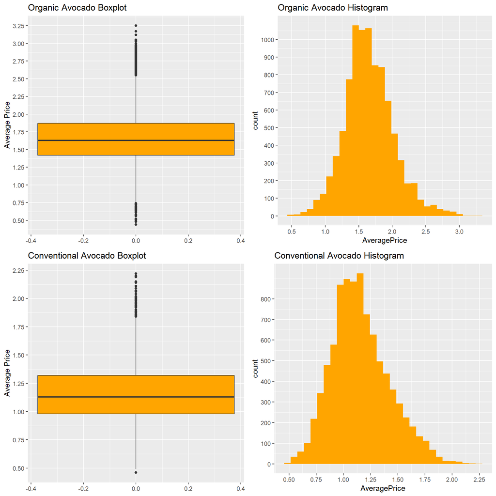

We can see in the chart above that the median price of organic avocados is ~50 cents higher than conventional avocados. The price distributions for both organic and conventional avocados are normally distributed.

People choose to buy organic avocados over conventional for a variety of reasons, but some of the reasons contribute to an increase in prices. There is typically a higher production cost associated with organic foods and the production and distribution chains are not nearly as robust. For these reasons and more, we should expect that the organic avocados are in general more expensive.

Now let’s take a look at the average avocado price over time and see if there are any trends.

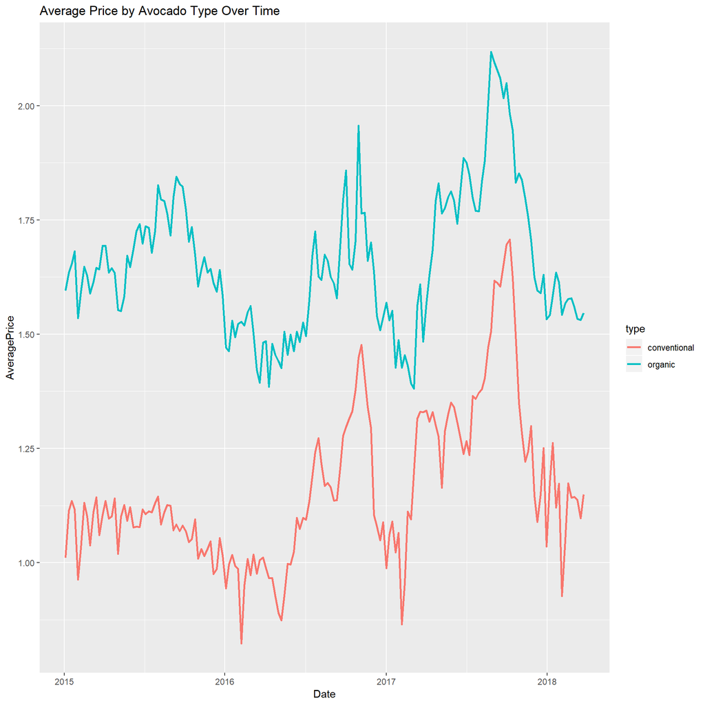

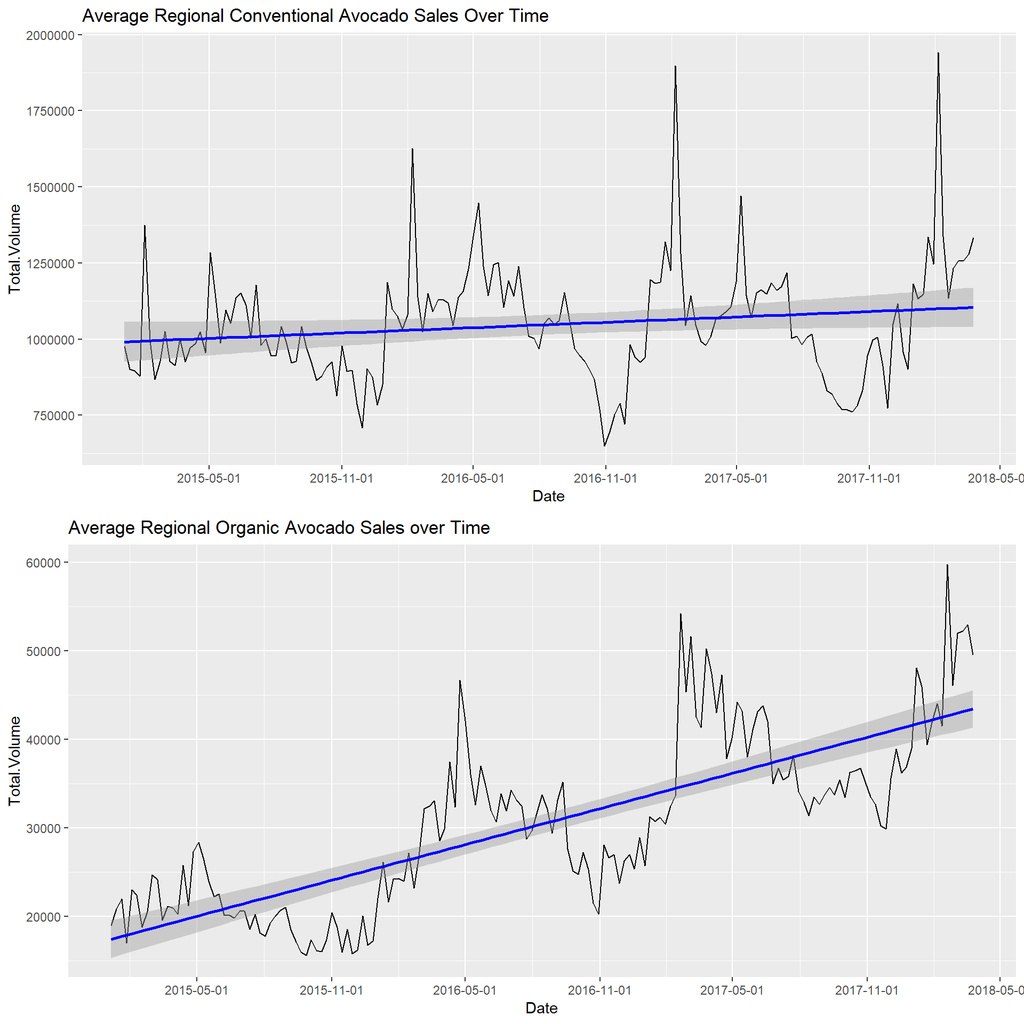

### How do the prices of avocados vary by region?

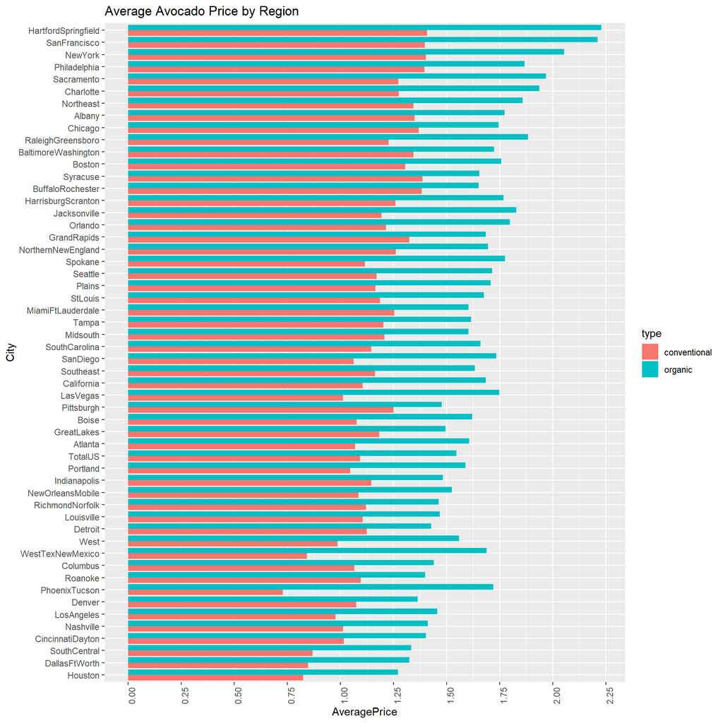

Reported statistics say that the majority of avocados consumed in the U.S. are produced either in Mexico or California. Based on that information, I would expect that regions along the southern and western US borders have the lowest distribution costs and therefore lower prices.

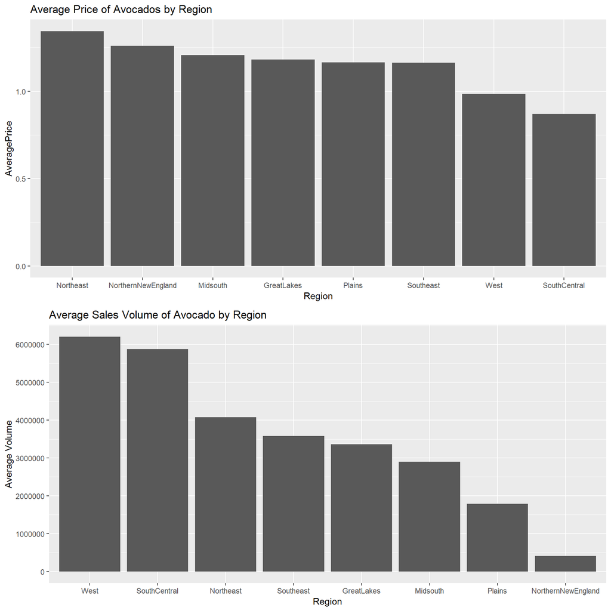

Here we can see the distribution costs reflected in the average price by region. The South-Central, West, and and South-East regions have the lowest average price whereas the North-East and New England regions have the highest. I would also guess that avocado availability is less sensitive to the seasonal changes in the south and west. This combined with the price discrepancy probably contributes significantly to these regions high average sales volumes.